# Predicting normative ratings of images from the Socio-Moral Image Database using visual features from AlexNet

Damien Crone

Previous research has shown that deep convolutional neural networks (such as AlexNet; [Krizhevsky et al, 2012](http://papers.nips.cc/paper/4824-imagenet-classification-with-deep-convolutional-neural-networks)) can explain a substantial proportion of variance in human similarity judgments (e.g., [Jozwik et al., 2017](http://journal.frontiersin.org/article/10.3389/fpsyg.2017.01726/full)).

In this document, I use features from a pre-trained neural network (AlexNet), obtained using the MATLAB Deep Learning Toolbox (see separate MATLAB code), to estimate normative ratings of various moral and emotional features of images from the Socio-Moral Image Database ([Crone et al., 2018](https://dx.doi.org/10.1371/journal.pone.0190954), osf.io/2rqad/), using cross-validated, penalized regression.

```r
library(caret)
# Specify variables to be predicted
dv_vec = c(
  "harm_mean", "fairness_mean", "ingroup_mean", "authority_mean", "purity_mean",
  "moral_mean", "valence_mean", "arousal_mean"
)
# Load norms from original norming study (Crone et al. 2018, PLoS ONE,
# https://osf.io/2rqad/), and reduce to variables to be predicted
smid_norms = read.csv(
  file = "~/Desktop/smid_norms.csv",
  row.names = 1
)
smid_norms = smid_norms[,dv_vec]
# Load final layer of alexnet and add to SMID norms
alexnet_fc8 = read.csv("~/Desktop/alexnet_fc8.csv", row.names = 1)
alexnet_fc8 = alexnet_fc8[rownames(smid_norms),]
smid_norms[, colnames(alexnet_fc8)] = NA
smid_norms[, colnames(alexnet_fc8)] = alexnet_fc8
alexnet_fc8_vec = colnames(alexnet_fc8)
rm(alexnet_fc8)
```

In the code below, for each of the 8 outcome variables, I perform 4-fold cross-validation with 10 random partitions of the data, using the Lasso method in the `caret` package. In each model, the outcome variable (e.g., each image’s average valence rating) is modelled as a weighted linear combination of the 1000-dimensional feature vector obtained from the final fully-connected layer (FC8) of AlexNet.

```r
# Initialise results list
reg_list = list()

# Specify cross-validation parameters
n_folds = 4
n_repeats = 10

# Perform cross-validated regressions for each outcome variable
for (dv in dv_vec) {

  f = as.formula(paste(dv, " ~ ", paste(alexnet_fc8_vec, collapse = " + ")))

  # Select cases with available data
  col_ind = c(dv, alexnet_fc8_vec)
  row_ind = complete.cases(smid_norms[, col_ind])
  mod_dat = smid_norms[row_ind, col_ind]

  set.seed(123)
  reg_list[[dv]] = train(
    form = f,
    data = mod_dat,
    method = "lasso",
    trControl = trainControl(
      method = "repeatedcv",
      number = n_folds,
      repeats = n_repeats,
      verboseIter = FALSE
    )
  )

}
```

As shown in the table and figure below, the AlexNet features were able to succesfully predict normative ratings on all dimensions, however R-squared values were not exceptionally high, ranging from .14 (Morality) to .22 (Authority). Given that AlexNet was originally trained for 1000-way object classification, rather than predicting abstract semantic dimensions, such is perhaps unsurprising.

```r
# Extract R^2 values for final models
results = data.frame(
  Outcome = dv_vec,
  RSquared = sapply(X = reg_list, FUN = function(x) round(max(x$results$Rsquared), 3)),
  row.names = NULL
)
results = results[order(results$RSquared, decreasing = TRUE),]
print(results)
```

|  | Outcome | RSquared |
| --- | --- | --- |
| 4 | authority_mean | 0.218 |
| 3 | ingroup_mean | 0.180 |
| 1 | harm_mean | 0.167 |
| 7 | valence_mean | 0.161 |
| 8 | arousal_mean | 0.161 |
| 5 | purity_mean | 0.151 |
| 2 | fairness_mean | 0.148 |
| 6 | moral_mean | 0.138 |

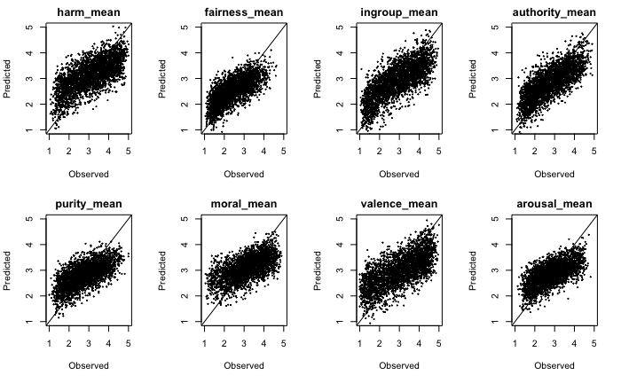

```r
par(mfrow = c(2, 4))
for (dv in dv_vec) {
  # Select cases with available data
  col_ind = c(dv, alexnet_fc8_vec)
  row_ind = complete.cases(smid_norms[, col_ind])
  mod_dat = smid_norms[row_ind, col_ind]
  set.seed(123)
  mod_pred = predict(
    object = reg_list[[dv]],
    bewdata = mod_dat[, alexnet_fc8_vec]
  )

  plot(
    x = mod_dat[, dv],
    y = mod_pred,
    xlim = c(1, 5),
    ylim = c(1, 5),
    main = dv,
    xlab = "Observed",
    ylab = "Predicted",
    cex = 1/5
  )

  abline(a = c(0, 1))
}
```

```r
save(reg_list, file = "reg_list.RData")
```